# Data Import and Processing

### Precision calculation

`dmPrecision` is used to estimate the precision by maximum likelihood. It is inversely related to the dispersion in the DM model via following relation: $dispersion = \frac{1}{1 + precision}$. `dmFit` is used to fit regression coefficients and estimate feature propotrions for each sample. `dmTest` is used to perform null hypothesis likelihood ratio testing on `day5`. `plotPrecision` is used to plot precision (y-axis) against mean expression (x-axis). In RNA-seq data there is usually a trend of decrease of dispersion (here, increase of precision) with increase of mean expression. This is the trend observed here.

```r
system.time({
  d <- dmPrecision(d, design=design_full)
  d <- dmFit(d, design=design_full)
})
```

```
! Using a subset of 0.1 genes to estimate common precision !
```

```
! Using common_precision = 21.2862 as prec_init !
```

```
! Using loess fit as a shrinkage factor !
```

```
   user  system elapsed
622.371   3.483 638.365
```

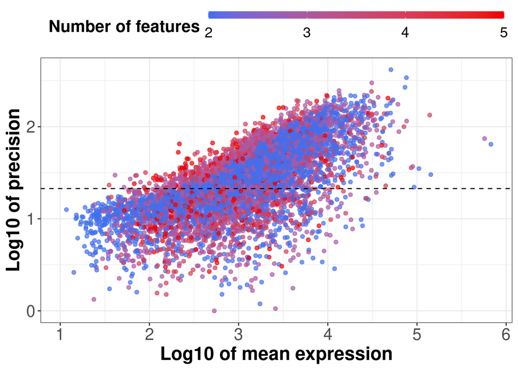

```r
plotPrecision(d)
```

```r
# Numeric vector of mean gene expression.
head(mean_expression(d))
```

```
             gene_id mean_expression
1 ENSG00000052841.15       4246.4306
2  ENSG00000256591.5        377.4107
3  ENSG00000255471.1        108.7104
4 ENSG00000149328.15        174.1209
5 ENSG00000111186.13       3568.7414
6 ENSG00000111224.14        860.1869
```

```r
# Numeric value of estimated common precision.
common_precision(d)
```

```
[1] 21.28624
```

```r
# Numeric vector of estimated gene-wise precisions.
head(genewise_precision(d))
```

```
             gene_id genewise_precision
1 ENSG00000052841.15          70.800532
2  ENSG00000256591.5          27.737903
3  ENSG00000255471.1                 NA
4 ENSG00000149328.15                 NA
5 ENSG00000111186.13           5.373339
6 ENSG00000111224.14          11.627499
```

```r
## Get fitted proportions - estimated feature ratios for each sample
head(proportions(d))
```

```
             gene_id         feature_id day0.rep1 day0.rep2 day0.rep3 day1.rep1
1 ENSG00000052841.15         BambuTx100 0.1839865 0.1839865 0.1839865 0.1985653
2 ENSG00000052841.15  ENST00000039989.9 0.5718858 0.5718858 0.5718858 0.5620527
3 ENSG00000052841.15 ENST00000299240.10 0.2441277 0.2441277 0.2441277 0.2393820
4  ENSG00000256591.5         BambuTx102 0.3369753 0.3369753 0.3369753 0.4484651
5  ENSG00000256591.5  ENST00000536670.5 0.4133106 0.4133106 0.4133106 0.3925292
6  ENSG00000256591.5  ENST00000541135.5 0.2497141 0.2497141 0.2497141 0.1590057
  day2.rep1 day3.rep1 day3.rep2 day4.rep1 day5.rep1 day5.rep2 day5.rep3
1 0.1146795 0.2187214 0.2187214 0.1995248 0.2203314 0.2203314 0.2203314
2 0.5777165 0.5230367 0.5230367 0.5293489 0.5704172 0.5704172 0.5704172
3 0.3076040 0.2582419 0.2582419 0.2711263 0.2092514 0.2092514 0.2092514
4 0.3755887 0.4164650 0.4164650 0.4029053 0.4589542 0.4589542 0.4589542
5 0.3137564 0.3564449 0.3564449 0.2214526 0.2033833 0.2033833 0.2033833
6 0.3106549 0.2270901 0.2270901 0.3756421 0.3376625 0.3376625 0.3376625
```

```r
## Get the DM regression coefficients (gene-level)
head(coefficients(d))
```

```
             gene_id         feature_id X.Intercept.        day1       day2
1 ENSG00000052841.15         BambuTx100   -0.2828292 0.095886410 -0.7038428
2 ENSG00000052841.15  ENST00000039989.9    0.8512479 0.002287141 -0.2209780
3 ENSG00000052841.15 ENST00000299240.10    0.0000000 0.000000000  0.0000000
4  ENSG00000256591.5         BambuTx102    0.2996931 0.737197903 -0.1098811
5  ENSG00000256591.5  ENST00000536670.5    0.5038826 0.399788318 -0.4939482
6  ENSG00000256591.5  ENST00000541135.5    0.0000000 0.000000000  0.0000000
         day3        day4        day5
1  0.11673115 -0.02381714  0.33442514
2 -0.14549291 -0.18218494  0.15158352
3  0.00000000  0.00000000  0.00000000
4  0.30676255 -0.22962832  0.00721034
5 -0.05304971 -1.03231098 -1.01083724
6  0.00000000  0.00000000  0.00000000
```

```r
## Get the BB regression coefficients (feature-level)
head(coefficients(d), level = "feature")
```

```
             gene_id         feature_id X.Intercept.        day1       day2
1 ENSG00000052841.15         BambuTx100   -0.2828292 0.095886410 -0.7038428
2 ENSG00000052841.15  ENST00000039989.9    0.8512479 0.002287141 -0.2209780
3 ENSG00000052841.15 ENST00000299240.10    0.0000000 0.000000000  0.0000000
4  ENSG00000256591.5         BambuTx102    0.2996931 0.737197903 -0.1098811
5  ENSG00000256591.5  ENST00000536670.5    0.5038826 0.399788318 -0.4939482
6  ENSG00000256591.5  ENST00000541135.5    0.0000000 0.000000000  0.0000000
         day3        day4        day5
1  0.11673115 -0.02381714  0.33442514
2 -0.14549291 -0.18218494  0.15158352
3  0.00000000  0.00000000  0.00000000
4  0.30676255 -0.22962832  0.00721034
5 -0.05304971 -1.03231098 -1.01083724
6  0.00000000  0.00000000  0.00000000
```

### Testing and results

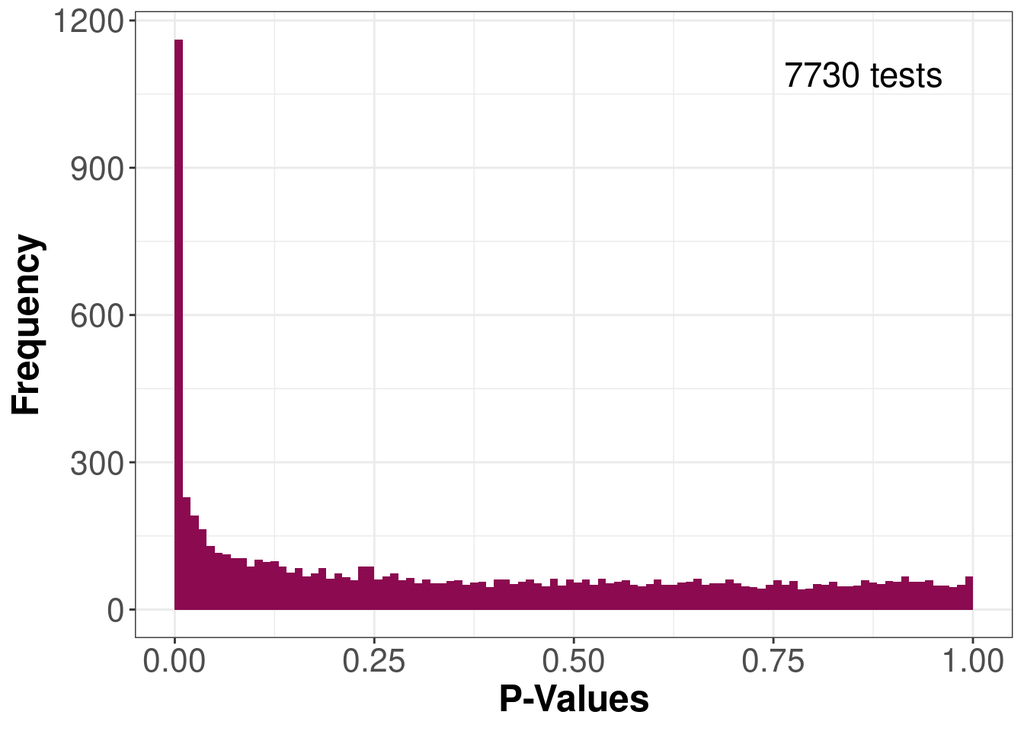

```r
## Fit null model proportions and perform the LR test to detect DTU
d <- dmTest(d, coef="day5")

## Plot the gene-level p-values
plotPValues(d)
```

```r
## Get the gene-level results
## Plot feature proportions for a top DTU gene
res <- DRIMSeq::results(d)
res <- res[order(res$pvalue, decreasing = FALSE), ]

### Get the feature-level results
res.txp <- DRIMSeq::results(d, level="feature")
res.txp <- res.txp[order(res.txp$pvalue, decreasing = FALSE), ]

# Significant gene results
idx <- which(res$adj_pvalue < 0.05)
head(res[idx,])
```

```
                gene_id       lr df       pvalue   adj_pvalue
7368 ENSG00000112759.19 288.8221  1 8.978826e-65 6.940632e-61
3863 ENSG00000171634.19 256.5601  3 2.493989e-55 9.639269e-52
1659 ENSG00000129422.15 199.6302  3 5.070757e-43 1.306565e-39
4889 ENSG00000107554.17 181.0145  2 4.933975e-40 9.534906e-37
4023 ENSG00000172889.16 157.8993  1 3.255727e-36 5.033354e-33
4219 ENSG00000164587.13 156.3295  2 1.131041e-34 1.457157e-31
```

```r
length(idx)
```

```
[1] 1050
```

```r
# Significant isoform results
idx.txp <- which(res.txp$adj_pvalue < 0.05)
head(res.txp[idx.txp,])
```

```
                 gene_id        feature_id       lr df       pvalue
20181 ENSG00000112759.19 ENST00000371755.9 288.8221  1 8.978826e-65
20182 ENSG00000112759.19 ENST00000393844.7 288.8221  1 8.978826e-65
13318 ENSG00000107554.17 ENST00000543621.6 179.9037  1 5.086884e-41
10876 ENSG00000172889.16 ENST00000371698.3 157.8993  1 3.255727e-36
10877 ENSG00000172889.16 ENST00000406555.7 157.8993  1 3.255727e-36
11418 ENSG00000164587.13 ENST00000312037.6 152.7979  1 4.240819e-35
        adj_pvalue
20181 8.966705e-61
20182 8.966705e-61
13318 3.386678e-37
10876 1.300533e-32
10877 1.300533e-32
11418 1.411698e-31
```

```r
length(idx.txp)
```

```
[1] 1459
```

*pvalue* may contain NA values which may cause downstream errors (in stagewise analysis by `stageR`) so they are converted to 1`s.

```r
no.na <- function(x) ifelse(is.na(x), 1, x)
res$pvalue <- no.na(res$pvalue)
res.txp$pvalue <- no.na(res.txp$pvalue)
```

### Plotting

For a given gene, plot the observed and estimated with Dirichlet-multinomial model feature proportions in each group. Estimated group proportions are marked with diamond shapes.

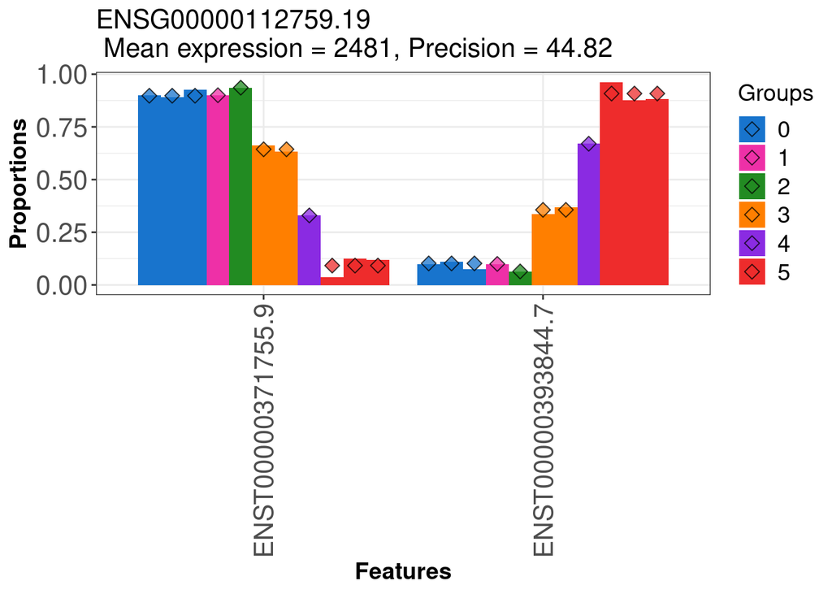

```r
top_gene_id <- res$gene_id[1]
plotProportions(d, gene_id = top_gene_id, group_variable = "day")
```

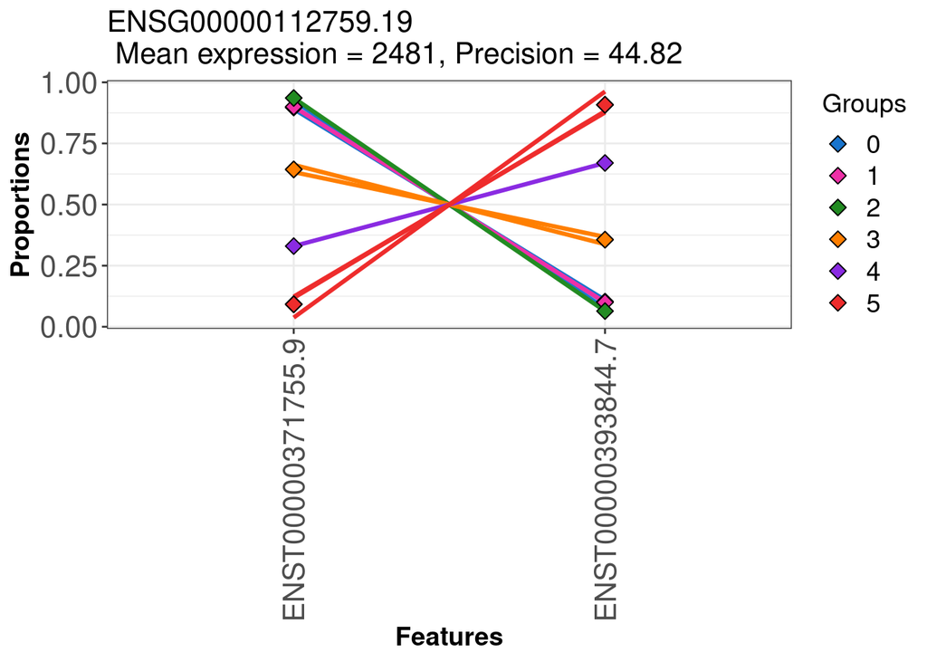

```r
plotProportions(d, gene_id = top_gene_id, group_variable = "day",
  plot_type = "lineplot")
```

[output not shown]

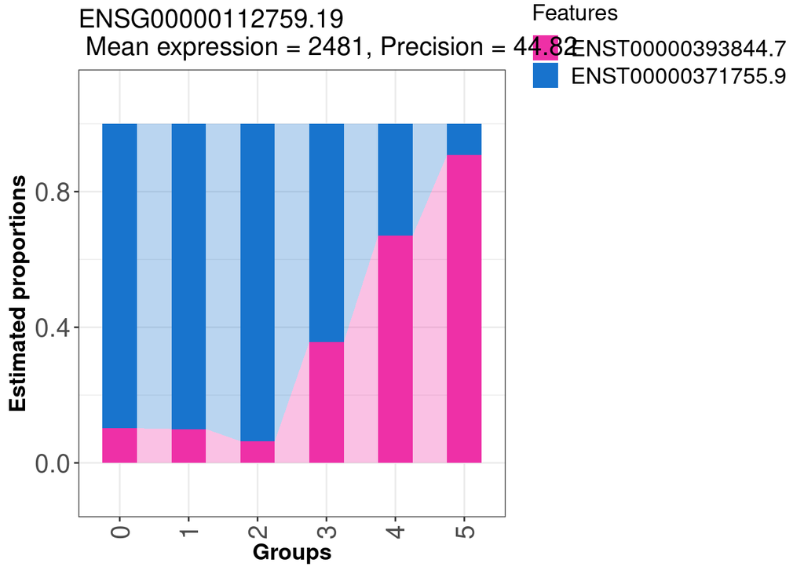

```r
plotProportions(d, gene_id = top_gene_id, group_variable = "day",
  plot_type = "ribbonplot")
```

### StageR following DRIMSeq

stageR package does stage-wise analysis of data, by screening first at the gene level for evidence of DTU (screening stage) and confirms which trancsripts within those significant genes show evidence of DTU (confirmation stage).

```r
nrow(res)
```

```
[1] 9901
```

A vector of per-gene p-values `pScreen` for the screening stage is constructed. Addiionally, the gene and transcript version numbers are stripped from their Ensembl IDs (only first 15 characters are kept).

```r
pScreen <- res$pvalue
strp <- function(x) substr(x,1,15)
names(pScreen) <- strp(res$gene_id)
```

A one column matrix of the confirmation p-values `pConfirmation` is constructed:

```r
pConfirmation <- matrix(res.txp$pvalue, ncol=1)
rownames(pConfirmation) <- strp(res.txp$feature_id)
```

A two column dataframe `tx2gene`with the transcript and gene identifiers is arranged:

```r
tx2gene <- res.txp[,c("feature_id", "gene_id")]
for (i in 1:2) tx2gene[,i] <- strp(tx2gene[,i])
```

`stageR` analysis is perform with *overall false discovery rate* (OFDR, alpha parameter) equal to 0.05.

```r
stageRObj <- stageRTx(pScreen=pScreen, pConfirmation=pConfirmation,
                      pScreenAdjusted=FALSE, tx2gene=tx2gene)
stageRObj <- stageWiseAdjustment(stageRObj, method="dtu", alpha=0.05)
suppressWarnings({
  drim.padj <- getAdjustedPValues(stageRObj, order=FALSE,
                                  onlySignificantGenes=TRUE)
})
```

```
The returned adjusted p-values are based on a stage-wise testing approach and are only valid for the provided target OFDR level of 5%. If a different target OFDR level is of interest,the entire adjustment should be re-run.
```

```r
head(drim.padj)
```

```
           geneID            txID         gene   transcript
1 ENSG00000112759 ENST00000371755 8.889936e-61 0.000000e+00
2 ENSG00000112759 ENST00000393844 8.889936e-61 0.000000e+00
3 ENSG00000107554 ENST00000543621 1.221282e-36 5.097696e-40
4 ENSG00000172889 ENST00000371698 6.446990e-33 0.000000e+00
5 ENSG00000172889 ENST00000406555 6.446990e-33 0.000000e+00
6 ENSG00000164587 ENST00000312037 1.866405e-31 4.249832e-34
```

```r
nrow(drim.padj)
```

```
[1] 3149
```

## DEXSeq

The filtered DRIMSeq object is used for DEXSeq workflow, as the filtering is easier, and the analysis is sped up. `DEXSeqDataSet` is built from `d`, filtered DRIMseq object, sample information (`sample.data`), a design formula, transcript ID and gene ID:

```r
sample.data <- DRIMSeq::samples(d)
# We start with already filtered DRIMSeq object
count.data <- round(as.matrix(counts(d)[,-c(1:2)]))
dxd <- DEXSeqDataSet(countData=count.data,
                     sampleData=sample.data,
                     design=~sample + exon + day:exon,
                     featureID=counts(d)$feature_id,
                     groupID=counts(d)$gene_id)
```

DEXSeq analysis is performed using the following 3 functions: (1) estimation of size factors using `estimateSizeFactors`, (2) estimation of dispersion `estimateDispersions`, then (3) perform a likelihood ratio test for differential exon usage (in this case, transcripts) `testForDEU`.

```r
system.time({
  dxd <- estimateSizeFactors(dxd)
  dxd <- estimateDispersions(dxd, quiet=TRUE)
  dxd <- testForDEU(dxd, reducedModel=~sample + exon)
})
```

```
24 rows did not converge in beta, labelled in mcols(object)$fullBetaConv. Use larger maxit argument with nbinomLRT
```

```
   user  system elapsed
 78.609   0.073  78.753
```

The results tables (log2 fold changes and p-values) can be generated using the `DEXSeqResults`function and `perGeneQValue` function is used to compute a per-gene adjusted p-value.

```r
dxr <- DEXSeqResults(dxd, independentFiltering=FALSE)
qval <- perGeneQValue(dxr)
# Per gene
dxr.g <- data.frame(gene=names(qval),qval)
# Per transcript
dxr.t = as.data.frame(dxr[, c("featureID","groupID","pvalue")])
head(dxr.g)
```

```
                                 gene         qval
ENSG00000000005.6   ENSG00000000005.6 1.000000e+00
ENSG00000000457.14 ENSG00000000457.14 9.537975e-01
ENSG00000000460.17 ENSG00000000460.17 9.362627e-08
ENSG00000001084.13 ENSG00000001084.13 3.136415e-01
ENSG00000001167.15 ENSG00000001167.15 1.000000e+00
ENSG00000001460.18 ENSG00000001460.18 1.198466e-01
```

Results:

```r
# Number of identified genes showing evidence for DTU
nrow(dxr.g[dxr.g$qval < 0.05,])
```

```
[1] 1457
```

```r
# Number of transcripts involved
nrow(dxr[dxr$padj < 0.05,])
```

```
[1] 2409
```

### stageR following DEXSeq

The code for the procedure is similar to DRIMSeq procedure, with `alpha=0.05`.

```r
strp <- function(x) substr(x,1,15)
pConfirmation <- matrix(dxr$pvalue,ncol=1)
dimnames(pConfirmation) <- list(strp(dxr$featureID),"transcript")
pScreen <- qval
names(pScreen) <- strp(names(pScreen))
tx2gene <-  data.frame(dxr.t[,c("featureID", "groupID")],
dxr.t[,c("featureID", "groupID")])
for (i in 1:2) tx2gene[,i] = strp(tx2gene[,i])
stageRObj <- stageRTx(pScreen=pScreen, pConfirmation=pConfirmation,
                      pScreenAdjusted=TRUE, tx2gene=tx2gene[1:2])
stageRObj = stageRTx(pScreen = pScreen,
pConfirmation = pConfirmation,
pScreenAdjusted = TRUE,
tx2gene = tx2gene[1:2])

stageRObj = stageWiseAdjustment(stageRObj, method = "dtu", alpha = 0.05)

suppressWarnings({
  dex.padj <- getAdjustedPValues(stageRObj, order=FALSE,
                                 onlySignificantGenes=TRUE)
})
```

```
The returned adjusted p-values are based on a stage-wise testing approach and are only valid for the provided target OFDR level of 5%. If a different target OFDR level is of interest,the entire adjustment should be re-run.
```

```r
dex.padj = merge(tx2gene, dex.padj, by.x = c("groupID","featureID"), by.y = c("geneID","txID"))

head(dex.padj)
```

```
          groupID       featureID       featureID.1          groupID.1
1 ENSG00000000460       BambuTx12         BambuTx12 ENSG00000000460.17
2 ENSG00000000460 ENST00000359326 ENST00000359326.9 ENSG00000000460.17
3 ENSG00000001497 ENST00000374807 ENST00000374807.9 ENSG00000001497.18
4 ENSG00000001497 ENST00000374811 ENST00000374811.8 ENSG00000001497.18
5 ENSG00000001497 ENST00000677834 ENST00000677834.1 ENSG00000001497.18
6 ENSG00000001497 ENST00000678602 ENST00000678602.1 ENSG00000001497.18
          gene   transcript
1 9.362627e-08 0.000000e+00
2 9.362627e-08 0.000000e+00
3 2.793368e-11 2.037362e-04
4 2.793368e-11 2.467069e-12
5 2.793368e-11 2.037362e-04
6 2.793368e-11 1.000000e+00
```

```r
length(unique(dex.padj[dex.padj$gene < 0.05,]$groupID))
```

```
[1] 1457
```

```r
table(dex.padj$transcript < 0.05)
```

```
FALSE  TRUE
 2315  2358
```

### Exporting the results

```r
dex.norm = cbind(as.data.frame(stringr::str_split_fixed(rownames(counts(dxd)), ":", 2)), as.data.frame(counts(dxd, normalized = TRUE))[,1:20])
colnames(dex.norm) = c("groupID", "featureID", as.character(colData(dxd)$sample_id)[1:20])
row.names(dex.norm) = NULL
# Per-group normalised mean
dex.mean = as.data.frame(sapply( levels(samps$day),
function(lvl) rowMeans(dex.norm[, 3:ncol(dex.norm)][, samps$day == lvl, drop = FALSE]) ))
colnames(dex.mean) <- paste0("mean.day", colnames(dex.mean))

# log2 fold change in expression
dex.log2fc = log2(dex.mean[2]/dex.mean[1])
colnames(dex.log2fc) = "log2fc"
rownames(dex.log2fc) = dex.norm$featureID

# Merge to create result data
dexData = cbind(dex.norm[,1:2], dex.mean, dex.norm[, 3:ncol(dex.norm)])
colnames(dexData)[1:2] <-  c("GeneID","TranscriptID")
dexData = dexData[order(dexData$GeneID, dexData$TranscriptID),]

# Merge to create result data
dexDTU = merge(dex.padj[,c("featureID.1","groupID.1","gene","transcript")], dex.log2fc, by.x = "featureID.1", by.y = "row.names")
colnames(dexDTU)[1:2] <-  c("TranscriptID","GeneID")
dexDTU = dexDTU[order(dexDTU$GeneID, dexDTU$TranscriptID),]
```

### Plotting

A custom function `plotExpression` was made to plot the transcript expression of a given gene as from

[figure not shown]

.

```r
# We will use this function in both DRIMSeq & DEXSeq workflows
plotExpression <- function(expData = NULL, geneID = NULL, samps = NULL, isProportion = FALSE) {
        colnames(expData)[1:2] = c("gid","tid")
        sub = subset(expData, gid == geneID)
        sub = reshape2::melt(sub, id = c("gid", "tid"))
        sub = merge(samps, sub, by.x = "sample_id", by.y = "variable")
        if(!isProportion) {
                sub$value = log(sub$value)
        }

        clrs = c("dodgerblue3", "maroon2",  "forestgreen", "darkorange1", "blueviolet", "firebrick2",
"deepskyblue", "orchid2", "chartreuse3", "gold", "slateblue1", "tomato" , "blue", "magenta", "green3",
"yellow", "purple3", "red" ,"darkslategray1", "lightpink1", "lightgreen", "khaki1", "plum3", "salmon")

        p = ggplot(sub, aes(tid, value, color = day, fill = day)) +
        geom_boxplot(alpha = 0.4, outlier.shape = NA, width = 0.8, lwd = 0.5) +
        stat_summary(fun = mean, geom = "point", color = "black", shape = 5, size = 3, position=position_dodge(width = 0.8)) +
        scale_color_manual(values = clrs) + scale_fill_manual(values = clrs) +
        geom_quasirandom(color = "black", size = 1, dodge.width = 0.8) + theme_bw() +
        ggtitle(geneID) + xlab("Transcripts")

        if(!isProportion) {
                p = p + ylab("log(Expression)")
        } else {
                p = p + ylab("Proportions")
        }
        p
}
```

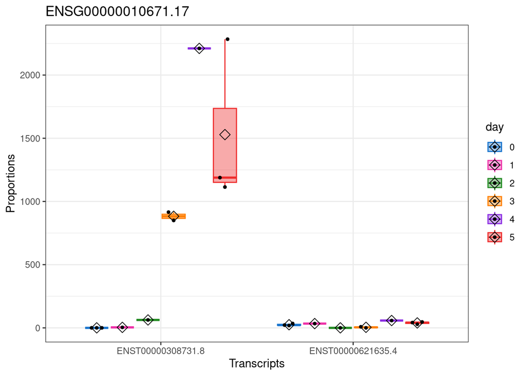

```r
# Plot the normalised counts for one of the significant genes, where we can see evidence of switching
gene_id <-  unique(dex.padj[order(dex.padj$transcript, dex.padj$gene),]$groupID.1)[1]
plotExpression(dex.norm, gene_id, samps, isProportion = T)
```

## Comparison of DRIMSeq and DEXSeq

```r
dim(dex.padj[order(dex.padj$gene, decreasing = T), ])
```

```
[1] 4673    6
```

Number of identified transcripts from DRIMSeq:

```r
dim(drim.padj[order(drim.padj$gene, decreasing = T), ])
```

```
[1] 3149    4
```

Check the intersection between the different methods for screened genes:

```r
length(intersect(dex.padj$groupID, drim.padj$geneID))
```

```
[1] 553
```

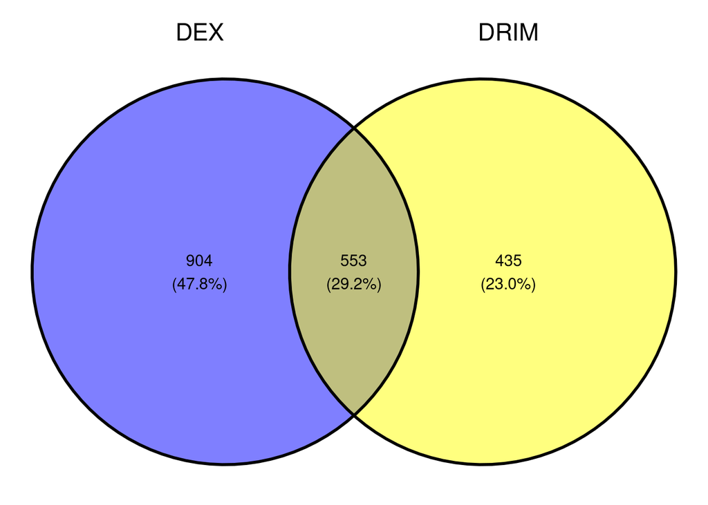

```r
venn <- list(DEX = dex.padj$groupID, DRIM = drim.padj$geneID)
ggvenn(venn)
```

Check the intersection between the different methods for features:

```r
length(intersect(dex.padj$featureID, drim.padj$txID))
```

```
[1] 1796
```

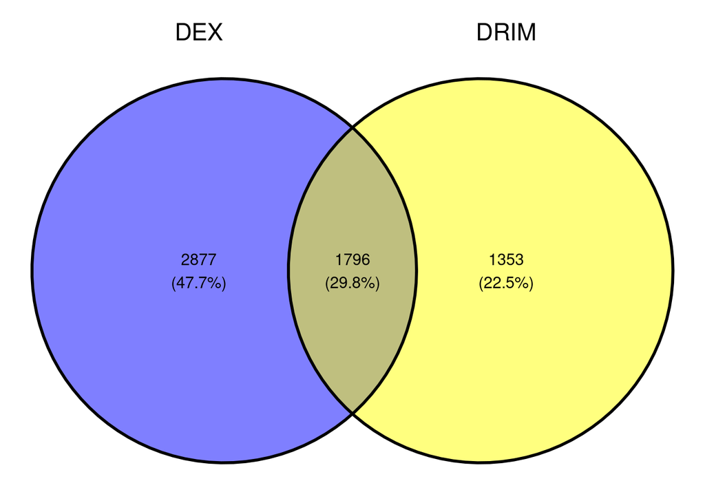

```r
venn <- list(DEX = dex.padj$featureID, DRIM = drim.padj$txID)
ggvenn(venn)
```

We can see that the intersection is quite low. However, we proceed with DEXSeq pipeline due to computer resource constraints.

# References

[1] Marques-Coelho, D., Iohan, L.d.C.C., Melo de Farias, A.R. et al. Differential transcript usage unravels gene expression alterations in Alzheimer’s disease human brains. npj Aging Mech Dis 7, 2 (2021). https://doi.org/10.1038/s41514-020-00052-5

[2] https://www.bioconductor.org/packages/release/workflows/vignettes/rnaseqDTU/inst/doc/rnaseqDTU.html

[3] Anders S, Reyes A, Huber W. Detecting differential usage of exons from RNA-seq data. Genome Res. 2012 Oct;22(10):2008-17. doi: 10.1101/gr.133744.111.

[4] Nowicka M, Robinson MD. DRIMSeq: a Dirichlet-multinomial framework for multivariate count outcomes in genomics. F1000Res. 2016 Jun 13;5:1356. doi: 10.12688/f1000research.8900.2.

[5] https://ycl6.gitbook.io/guide-to-rna-seq-analysis/differential-expression-analysis/differential-transcript-usage/dtu-using-dexseq

[6] Al’Khafaji, A.M., Smith, J.T., Garimella, K.V. et al. High-throughput RNA isoform sequencing using programmed cDNA concatenation. Nat Biotechnol (2023). https://doi.org/10.1038/s41587-023-01815-7